# Salmon River Carcass Analyses

Eric C. Anderson

Last Updated: 2020-05-14

Construct maps of the Salmon River basin and place carcass survey / RoSA genotype data on them. Compute relative frequencies of RoSA genotypes amongst spawners.

# Packages and paths

```r
library(tidyverse)
library(sf)
library(lubridate)
library(parallel)


dir.create("outputs/010", recursive = TRUE, showWarnings = FALSE)
```

# Selecting Map sources

## Get the watershed boundaries

```r
# grab and filter to the KLAMATH, and within that the Salmon River
salmon_bas <- st_read("geo-spatial/GISlayers_calw221_shp/calw221.shp") %>%
  filter(str_detect(HUNAME, "KLAMATH")) %>% # get just Klamath Basin
  filter(HANAME == "Salmon River") %>% # narrow it down to just Salmon River
  st_union() %>% # Keep just the outer basin boundary (not the trib basins within)
  st_transform(crs = 4326)
```

Plot it to make sure it is looking correct:

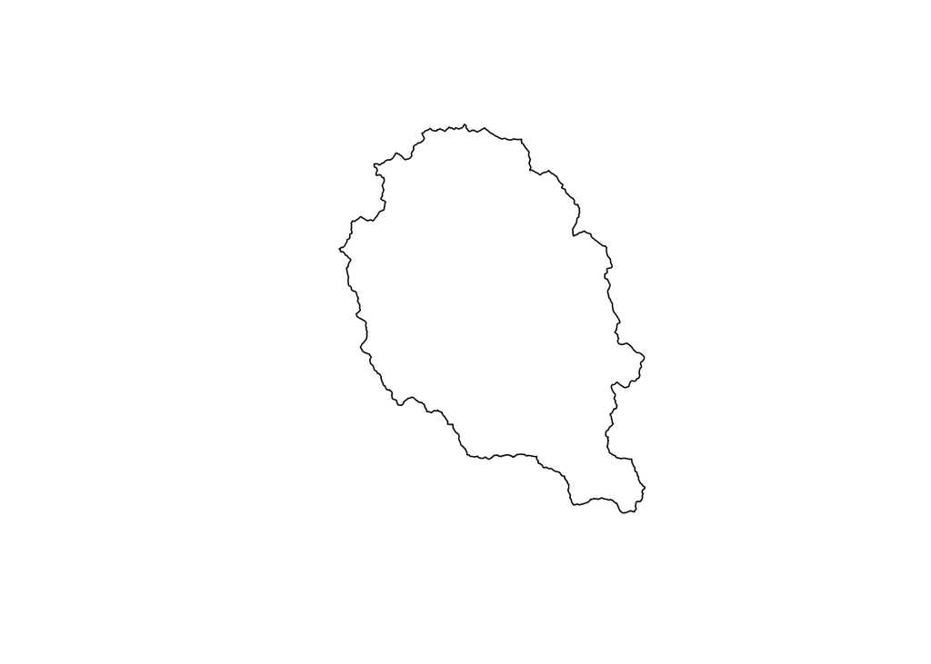

```r
plot(salmon_bas)
```

Yep.

## Get the stream lines

```r
salmon_riv <- st_read("geo-spatial/California_Streams/California_Streams.shp") %>%
  filter((str_detect(Hydrolog_1, "Klamath") & str_detect(Name, "Salmon")) |
    Hydrolog_2 == 18010210 & str_detect(Name, "Salmon"))
```

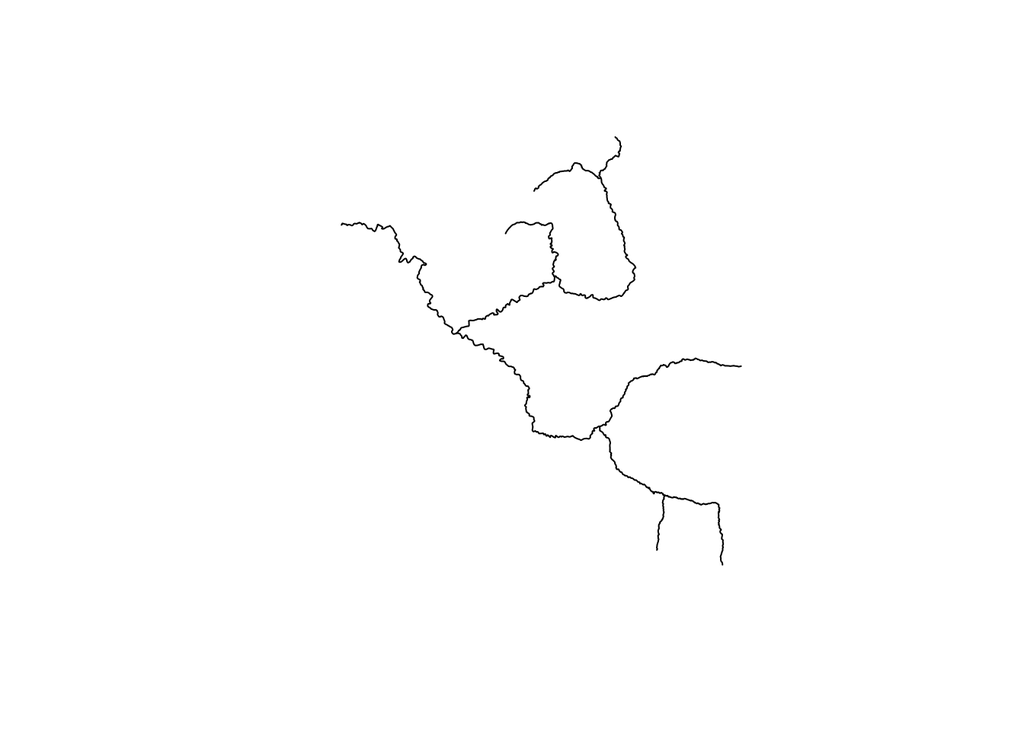

```r
# this gets written out here
write_rds(salmon_riv, path = "stored_results/010/salmon_riv.rds", compress = "xz")

# if you couldn't get California_Streams, that is OK,  just uncomment the following line:
# salmon_riv <- read_rds(path = "stored_results/010/salmon_riv.rds")

# plot it to make sure it looks right.
plot(st_geometry(salmon_riv))
```

Yep.

## plot the basin and the river together to confirm it looks good

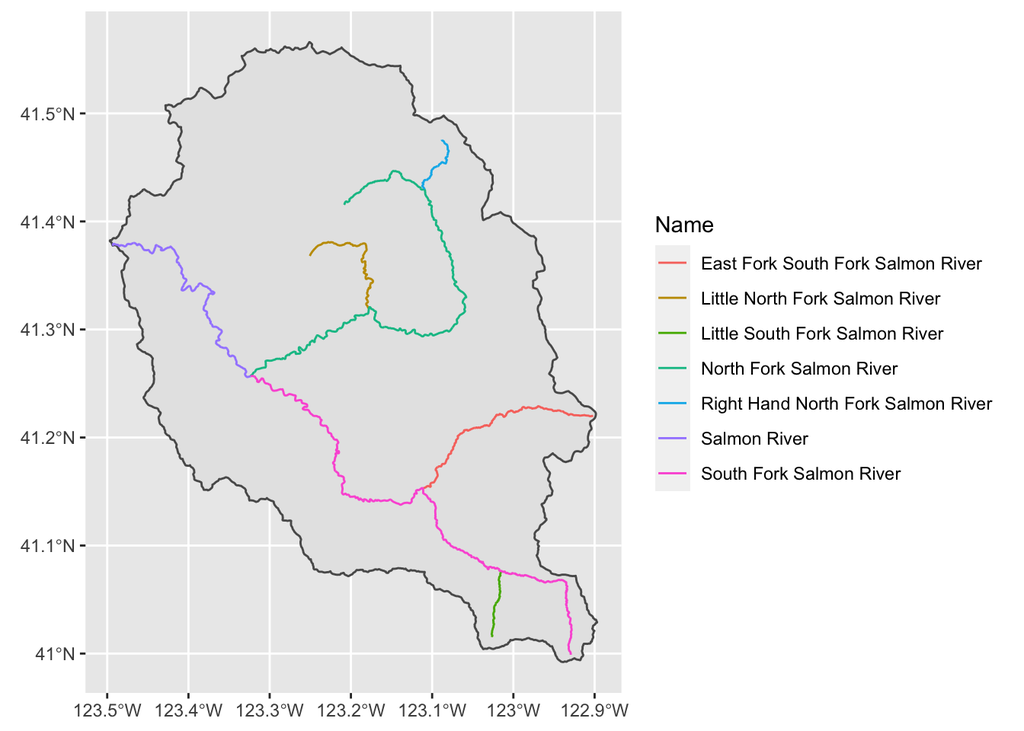

```r
ggplot() +
  geom_sf(data = salmon_bas) +
  geom_sf(data = salmon_riv, aes(colour = Name))
```

# Defining the reaches

Many of the carcasses are reported to have been sampled from one of a number of defined reaches in the river. Unfortunately, those reaches are not geo-referenced. So, we will have to use their descriptions from two fishery reports that are included in this repository:

- Table 2 in `reports/Meneks_2017-fall-run-survey.pdf`
- Table 1 in `reports/Meneks_2017B-spring-survey.pdf`

The data from both those tables was transcribed into `data/salmon_river_reaches.csv`.

We will count up the river miles as we go according to the tables in the reports. To do this we write a function that takes a line string, blows it into points, grabs the parts that we want based on distance from a starting point, and then put them all back together into a line string. This function is in `R/function_line_seg_by_distance.R`

```r
source("R/function_line_seg_by_distance.R")
```

Make a tibble has the hi and lo values for the reaches in miles, and then we can pick all of those out.

This block hangs, sometimes, when evaluated in the notebook. So, I’ve set eval=FALSE, and just have it read the result. But the code that generates it is all there.

```r
reach_spec <- read_csv("data/salmon_river_reaches.csv") %>%
  mutate(
    reach_lo = units::set_units(reach_lo, mile),
    reach_hi = units::set_units(reach_hi, mile)
  )

# now join those onto the geometries and then chop each part of them
# out of the respective tribs/rivers
units::units_options(allow_mixed = TRUE)
reach_geos <- reach_spec %>%
  left_join(salmon_riv, by = "Name") %>%
  mutate(geometry2 = mclapply(1:n(),
    function(i) line_seg_by_distance(geometry[i], reach_lo[[i]], reach_hi[[i]], asSFC = FALSE),
    mc.cores = 8
  ))

survey_reaches <- reach_geos %>%
  mutate(geometry = st_sfc(reach_geos$geometry2, crs = st_crs(reach_geos))) %>%
  select(-geometry2)

write_rds(survey_reaches, path = "stored_results/010/survey_reaches.rds", compress = "xz")
```

```r
survey_reaches <- read_rds(path = "stored_results/010/survey_reaches.rds")
```

```r
surv_reaches_lettered <- survey_reaches %>%
  filter(!(reach %in% c("4", "5", "6", "9", "10", "11"))) %>%
  mutate(reach_alt = factor(1:n() %% 2))

st_geometry(surv_reaches_lettered) <- surv_reaches_lettered$geometry
st_crs(surv_reaches_lettered) <- st_crs(salmon_riv)
```

Plot this to see where the reaches are.

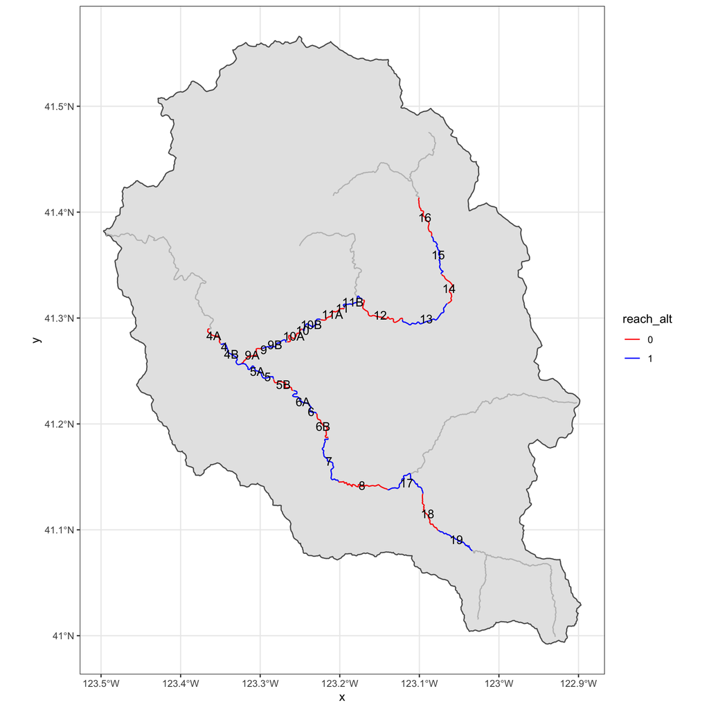

```r
# get the centroids of each survey reach
centroids <- survey_reaches %>%
  mutate(geometry = st_centroid(geometry))

g <- ggplot() +
  geom_sf(data = salmon_bas) +
  geom_sf(data = salmon_riv, colour = "gray") +
  geom_sf(data = surv_reaches_lettered, aes(colour = reach_alt)) +
  scale_colour_manual(values = c("red", "blue")) +
  geom_sf_text(data = centroids, aes(geometry = geometry, label = reach)) +
  theme_bw()

g
```

# Genetic Data

## Read and process all the Salmon River RoSA genotypes

Read data in. Some individuals were genotyped more than once. We filter out duplicates of the same NMFS_DNA_ID, keeping the one that has the highest number of successfully genotyped SNPs in the RoSA. We discard all SNPs scored as “?”, retaining only those individuals with 2 or more SNPs remaining.

We also record whether the carcass was recorded with a REACH where it was found.

```r
expando_rosa <- read_rds("data/salmon_river_spatiotemporal_rosa_data.rds") %>%
  mutate(Year = year(COLLECTION_DATE)) %>%
  mutate(
    gcomp = str_remove_all(hapstr, "\\?"),
    gcvec = strsplit(gcomp, ""),
    called_geno = case_when(
      nchar(gcomp) >= 2 & sapply(gcvec, function(x) all(x == "P")) ~ "S",
      nchar(gcomp) >= 2 & sapply(gcvec, function(x) all(x == "M")) ~ "F",
      nchar(gcomp) >= 2 & sapply(gcvec, function(x) all(x == "H")) ~ "H",
      nchar(gcomp) >= 2 & (map_int(gcvec, n_distinct) >= 2) ~ "A",
      TRUE ~ "M"
    )
  ) %>%
  mutate(RoSA_genotype = recode_factor(called_geno,
    "S" = "EE",
    "H" = "EL",
    "F" = "LL",
    "A" = "Ambiguous",
    "M" = "Missing"
  )) %>%
  mutate(HasReach = (!is.na(REACH_SITE) & REACH_SITE != "Cecilville")) %>% # Cecilville is not a valid reach and all of those have a lat-long that we will use.
  arrange(NMFS_DNA_ID, desc(nchar(gcomp))) %>%
  group_by(NMFS_DNA_ID) %>%
  mutate(rank = 1:n()) %>%
  filter(rank == 1) %>%
  ungroup() %>%
  select(-rank)
```

Read in extra meta-data that goes with those, so we can do lats and longs if they have them.

```r
expando_meta <- read_csv("data/SalmonRiver_RoSA_genotype_full_table_meta.csv") %>%
  select(NMFS_DNA_ID, LATITUDE_F, LONGITUDE_F) %>%
  rename(
    Lat = LATITUDE_F,
    Long = LONGITUDE_F
  ) %>%
  mutate(HasLatLong = ifelse(is.na(Lat), FALSE, TRUE))
```

## Add Lat-Longs where they are available

Join on the lat-longs

```r
expando_r_latlong <- expando_meta %>%
  left_join(expando_rosa, .) %>%
  filter(!is.na(Year))
```

## Count up what we have here

See how many have at least one of reach or lat/long:

```r
expando_r_latlong %>%
  filter(HasReach == TRUE | HasLatLong == TRUE)
```

| Indiv | Population | hapstr | NMFS_DNA_ID | PHENOTYPE | COLLECTION_DATE | REACH_SITE | LOCATION_COMMENTS_F | Sample_Plate | Year | gcomp | gcvec | called_geno | RoSA_genotype | HasReach | Lat | Long | HasLatLong |
| --- | --- | --- | --- | --- | --- | --- | --- | --- | --- | --- | --- | --- | --- | --- | --- | --- | --- |
| CH14865 | SalmonRiver | ????????? | T022276 | NA | 2006-10-27 | reach 10 | NA | T022276_T235_9F | 2006 |  |  | M | Missing | TRUE | NA | NA | FALSE |
| CH14877 | SalmonRiver | MMMMMMMMM | T022277 | NA | 2006-10-27 | reach 10 | NA | T022277_T235_9G | 2006 | MMMMMMMMM |  | F | LL | TRUE | NA | NA | FALSE |
| CH14889 | SalmonRiver | HHHHHHHHH | T022278 | NA | 2006-10-27 | reach 10 | NA | T022278_T235_9H | 2006 | HHHHHHHHH |  | H | EL | TRUE | NA | NA | FALSE |
| CH14862 | SalmonRiver | MMMMMMMMM | T022279 | NA | 2006-10-27 | reach 9 | NA | T022279_T235_10A | 2006 | MMMMMMMMM |  | F | LL | TRUE | NA | NA | FALSE |
| CH14874 | SalmonRiver | ???M??MM? | T022280 | NA | 2006-10-27 | reach 9 | NA | T022280_T235_10B | 2006 | MMM |  | F | LL | TRUE | NA | NA | FALSE |
| CH14886 | SalmonRiver | H?HHPPHH? | T022281 | NA | 2006-10-27 | reach 9 | NA | T022281_T235_10C | 2006 | HHHPPHH |  | A | Ambiguous | TRUE | NA | NA | FALSE |
| CH14898 | SalmonRiver | HHHHHHHHH | T022282 | NA | 2006-10-27 | reach 9 | NA | T022282_T235_10D | 2006 | HHHHHHHHH |  | H | EL | TRUE | NA | NA | FALSE |
| CH14910 | SalmonRiver | HHHHHHHHH | T022283 | NA | 2006-10-27 | reach 6 | NA | T022283_T235_10E | 2006 | HHHHHHHHH |  | H | EL | TRUE | NA | NA | FALSE |
| CH14922 | SalmonRiver | HHHHHHHHH | T022284 | NA | 2006-10-27 | reach 6 | NA | T022284_T235_10F | 2006 | HHHHHHHHH |  | H | EL | TRUE | NA | NA | FALSE |
| CH14934 | SalmonRiver | MMMMMMMMM | T022285 | NA | 2006-10-27 | reach 6 | NA | T022285_T235_10G | 2006 | MMMMMMMMM |  | F | LL | TRUE | NA | NA | FALSE |

[output cut: 391 more lines]

Take stock of what we’ve got by year, location, and genotype. And present that as a table.

```r
# summarise counts
yprg <- expando_r_latlong %>%
  count(Year, HasReach, HasLatLong, RoSA_genotype)

# spread over genotype
yprg_s <- yprg %>%
  spread(RoSA_genotype, n, fill = 0) %>%
  mutate(`Total n` = EE + EL + LL + Ambiguous + Missing)

# save that to a file:
write_csv(yprg_s, path = "outputs/010/SalmonRiver_RoSA_genotype_counts.csv")
```

## Give random lat-longs within reach for fish that have reach

Given what we see in the Location Comments Field (i.e. sometimes the lat-long is the location of a nearby landmark, possibly not near the river itself), it will be best to use the reach to identify position if it is available, unless it just says “Cecilville” as that is not a valid reach specifer (those indivs have lat-longs, though). If reach is not available, and the Lat/Long is available, then we will use the Lat/Long.

Here is a function to randomly sample a point from a linestring:

```r
rando_pt_from_linestring <- function(L) {
  lapply(L, function(x) {
    mat <- unclass(x)
    r <- sample(1:nrow(mat), 1)
    x[r, ]
  })
}
```

Now…

```r
# these have REACH
has_R <- expando_r_latlong %>%
  filter(HasReach == TRUE)

# these don't
no_R_LL <- expando_r_latlong %>%
  filter(HasReach == FALSE, HasLatLong == TRUE) %>%
  mutate(rLat = Lat, rLong = Long) # populate the rLat and rLong fields with the same values in these cases

set.seed(100)
tmp <- has_R %>%
  mutate(
    reach = str_replace_all(REACH_SITE, "[Rr]each ", ""),
    reach = ifelse(nchar(reach) < 5, reach, NA)
  ) %>% # the wipes out the Cecilvilles...they all have LatLong info.
  left_join(survey_reaches, by = "reach")

# grab the five fish in reach 1.  We have a lat-long location for that and we will
# just manually put the Reach 1 fish in there at that spot, and then wiggle it.
Reach1_fish <- tmp %>%
  filter(reach == 1) %>%
  mutate(
    rLat = 41.377819,
    rLong = -123.430
  )

has_R_LL <- tmp %>%
  filter(sapply(geometry, function(x) nrow(x) > 0)) %>% # some geometries were missing
  mutate(rando_point = rando_pt_from_linestring(geometry)) %>%
  mutate(
    rLong = map_dbl(rando_point, function(x) x["X"]),
    rLat = map_dbl(rando_point, function(x) x["Y"])
  )

# now pick out from that only the non-geometry columns
has_R_LL_pick <- has_R_LL[, c(names(no_R_LL), "rLat", "rLong")]
Reach1_fish_pick <- Reach1_fish[, c(names(no_R_LL), "rLat", "rLong")]


LL_by_reach_or_coords <- bind_rows(
  no_R_LL,
  has_R_LL_pick,
  Reach1_fish_pick
)
```

# Spatial and Spatio-temporal plots

## Make a plot of all the fish over all years

Now we have fish with decent Lat-Longs, sampled in the Salmon River from 1994 to 2018. Let’s see where the RoSA genotypes fall out, and we will include ambiguous and missing in here too.

We will jitter them, so we include seed.

```r
set.seed(5)
m9 <- ggplot() +
  geom_sf(data = salmon_bas, fill = "#e5f5e0") +
  geom_sf(data = salmon_riv, colour = "gray") +
  scale_colour_manual(values = c("#a6bddb", "black")) +
  theme_bw() +
  geom_jitter(
    data = LL_by_reach_or_coords, aes(x = rLong, y = rLat, fill = RoSA_genotype), shape = 21, stroke = 0.3, colour = "black",
    size = 2.5, width = .02, height = .02
  ) +
  geom_sf(data = surv_reaches_lettered, aes(geometry = geometry, colour = reach_alt), show.legend = FALSE) +
  scale_fill_manual(values = c(
    `LL` = "blue",
    `EE` = "gold",
    `EL` = "tan2",
    `Ambiguous` = "red",
    `Missing` = "black"
  )) +
  facet_wrap(~RoSA_genotype, ncol = 2) +
  theme(axis.text.x = element_text(angle = 90, vjust = 0.5)) +
  xlab("Longitude") +
  ylab("Latitude") +
  labs(fill = "RoSA Genotype")

ggsave(m9, filename = "outputs/010/salmon-river-map-all-years-faceted-by-geno.pdf", width = 7, height = 10)
```

## Plot the 2006 fish in 14-day bins

2006 has sufficient fish to make it worthwhile to break the carcass recoveries down by date.

```r
alls_2006 <- LL_by_reach_or_coords %>%
  filter(Year == 2006 & !(RoSA_genotype %in% c("Missing", "Ambiguous")))

# we can carve up the sample dates into 14-day blocks
date_ints <- seq(from = ymd("2006-9-18"), to = ymd("2006-12-14"), by = 14)

# and we will name those intervals according to the middle day in each
dint_names <- date_ints[-1] - 7

alls_2006_weeked <- alls_2006 %>%
  mutate(mid_week_day = cut(COLLECTION_DATE, breaks = date_ints, labels = dint_names))
```

Now, with that, we can facet our way down the weeks:

```r
set.seed(5)
m15 <- ggplot() +
  geom_sf(data = salmon_bas, fill = "#e5f5e0") +
  geom_sf(data = salmon_riv, colour = "gray") +
  scale_colour_manual(values = c("#a6bddb", "black")) +
  theme_bw() +
  geom_jitter(
    data = alls_2006_weeked, aes(x = rLong, y = rLat, fill = RoSA_genotype), shape = 21, stroke = 0.3, colour = "black",
    size = 2.5, width = .02, height = .02
  ) +
  geom_sf(data = surv_reaches_lettered, aes(geometry = geometry, colour = reach_alt), show.legend = FALSE) +
  scale_fill_manual(values = c(
    `LL` = "blue",
    `EE` = "gold",
    `EL` = "tan2"
  )) +
  facet_grid(RoSA_genotype ~ mid_week_day) +
  theme(axis.text.x = element_text(angle = 90, vjust = 0.5)) +
  xlab("Longitude") +
  ylab("Latitude") +
  labs(fill = "RoSA Genotype")


ggsave(m15, filename = "outputs/010/salmon-river-spatiotemporal-map-2006.pdf", width = 12, height = 8)
```

# Genotype Frequency Plots

From the above assessment, it appears that some years have too few successfully genotyped fish to be very informative. So, we will filter down to only those years that have at least 20 successful genotypes. We could do some thing where we estimate frequencies given counts of the ambiguous and missing ones as well, but I feel that is overkill. Missingness is unlikely correlated with RoSA genotype. So, we will filter out the missing and ambiguous ones, and do the analysis on that.

```r
for_hwe <- yprg %>%
  ungroup() %>%
  filter(RoSA_genotype %in% c("LL", "EL", "EE")) %>%
  mutate(RoSA_genotype = fct_drop(RoSA_genotype)) %>%
  group_by(Year) %>%
  filter(sum(n) >= 20)

# then lump all the "populations" together in each year and compute observed frequencies
# as well as expected frequencies under HWE
fhwe_tots <- for_hwe %>%
  group_by(Year, RoSA_genotype, .drop = FALSE) %>% # .drop = FALSE to get explicit 0's
  summarise(N = sum(n)) %>%
  mutate(
    freq = N / sum(N),
    NS = 2 * N[RoSA_genotype == "EE"] + N[RoSA_genotype == "EL"],
    NF = 2 * N[RoSA_genotype == "LL"] + N[RoSA_genotype == "EL"],
    fS = NS / (NS + NF),
    fF = NF / (NS + NF)
  ) %>%
  mutate(hwe_exp_freq = c(fS[1]^2, 2 * fF[1] * fS[1], fF[1]^2)) %>%
  mutate(hwe_exp_n = hwe_exp_freq * sum(N))
```

Now, make a table of the relevant numbers here:

```r
hwetab <- fhwe_tots %>%
  select(Year, RoSA_genotype, N, hwe_exp_n)

hwetab
```

| Year | RoSA_genotype | N | hwe_exp_n |
| --- | --- | --- | --- |
| 1997 | EE | 23 | 23.08653846 |
| 1997 | EL | 3 | 2.82692308 |
| 1997 | LL | 0 | 0.08653846 |
| 2006 | EE | 23 | 18.49864865 |
| 2006 | EL | 71 | 80.00270270 |
| 2006 | LL | 91 | 86.49864865 |
| 2014 | EE | 0 | 0.10775862 |
| 2014 | EL | 5 | 4.78448276 |
| 2014 | LL | 53 | 53.10775862 |
| 2017 | EE | 5 | 3.25000000 |

[output cut: 5 more lines]

```r
hwefig <- ggplot(hwetab %>% filter(Year > 1997 & Year != 2014)) +
  geom_col(aes(x = RoSA_genotype, y = N, fill = RoSA_genotype)) +
  geom_col(aes(x = RoSA_genotype, y = hwe_exp_n), fill = NA, colour = "green", size = 0.5) +
  geom_col(aes(x = RoSA_genotype, y = hwe_exp_n),
    fill = NA, colour = "black", size = 0.5,
    linetype = "dashed"
  ) +
  scale_fill_manual(values = c(
    `LL` = "blue",
    `EE` = "gold",
    `EL` = "tan2"
  )) +
  facet_wrap(~Year, nrow = 1) +
  theme_bw()


ggsave(hwefig, filename = "outputs/010/salmon-river_hwe_counts-3-panel.pdf", width = 8, height = 3)
```

# Running Time

Running the code and rendering this notebook required approximately this much time on a Mac laptop of middling speed:

```r
Sys.time() - start_time
```

```
## Time difference of 50.76669 secs
```

Citations